# Table Joins

#### Objectives

- Understand the structure of a joined table
- Familiarity with the different join types
- Use different join types in analysing your data
- Understand what other join types can tell you about your data

## About table joins

- In any relational database system, the ability to join tables together is a key querying requirement.
- `Joins` are used to combine the rows from two (or more) tables together to form a single table.
- A join between tables will only be possible if they have at least `one column in common`.
- The column doesn’t have to have the same name in each table, and quite often they won’t, but they do have to have a common usage.
- For example the Question1 table has been created from the information about Q1 in the SN7577 data dictionary file.
- There are only two columns The value column indicates a respondents voting intentions and the key column has the value which is used to represent this intention in the SN7577 table.
- You can see immediately from this that there is a connection or relationship between the the two tables.
- The key column in the Question1 table has been defined as a primary key.
- This guarantees that the key column has a unique set of values.
- Although not required, it is generally the case that the values in one of the columns that the tables have in common will have unique values in it.
- It is also not required but generally the case that the unique column will be a primary key in one of the tables.
- In the `SN7577` table, the values in the `Q1 column` are the `key values` in the `Q1 table`.
- You would not expect these to be unique, many respondents may have the same voting intentions.
- If we wanted to find out the voting intentions of all of the respondents we could write a simple aggregation query like this:

```sql
SELECT Q1,
       count(*) as how_many
FROM SN7577
GROUP BY Q1;
```

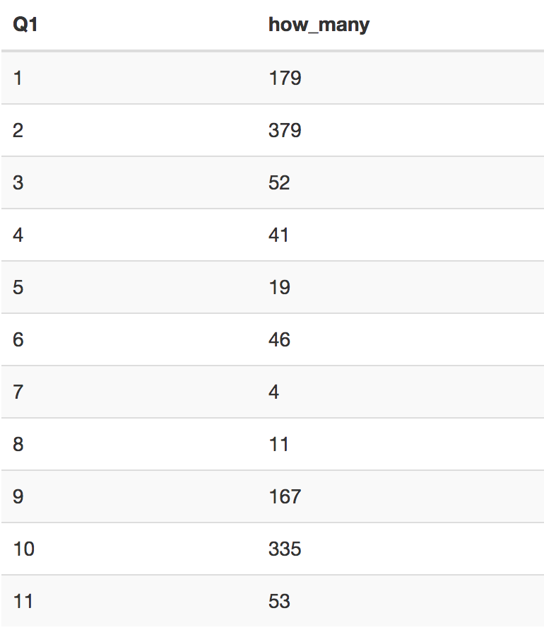

image

## INNER JOIN

- What we would really like would be to have the text values of the voting intentions to make the results more readable.
- We can achieve this by joining the Question1 table with the SN7577 table.
- Table names like column names can be given an alias.
- This is almost always done when joining tables.
- There are two reasons for doing this.
1. In the select clause you can make it clear from which table each of the selected columns comes from by prefixing the column name with the table alias followed by a period. You could use the full table name but by selecting short, single letter alias’ you can save a lot of typing.
2. The column names that you wish to join on may have the same name and so you need some way of distinguishing between them.

Using simple alias’ for the tables our join SQL looks like this:

```sql
SELECT q.value,
       count(*) as how_many
FROM SN7577 s
JOIN Question1  q
ON q.key = s.Q1
GROUP BY  s.Q1
```

- Here we have selected the `value` column from the `Question1 table` as this has the text value that we want.
- The aggregation remains the same.
- The `JOIN clause` names the second table and the `ON clause` gives the criteria by which the tables are to be joined.
- The results obtained are:

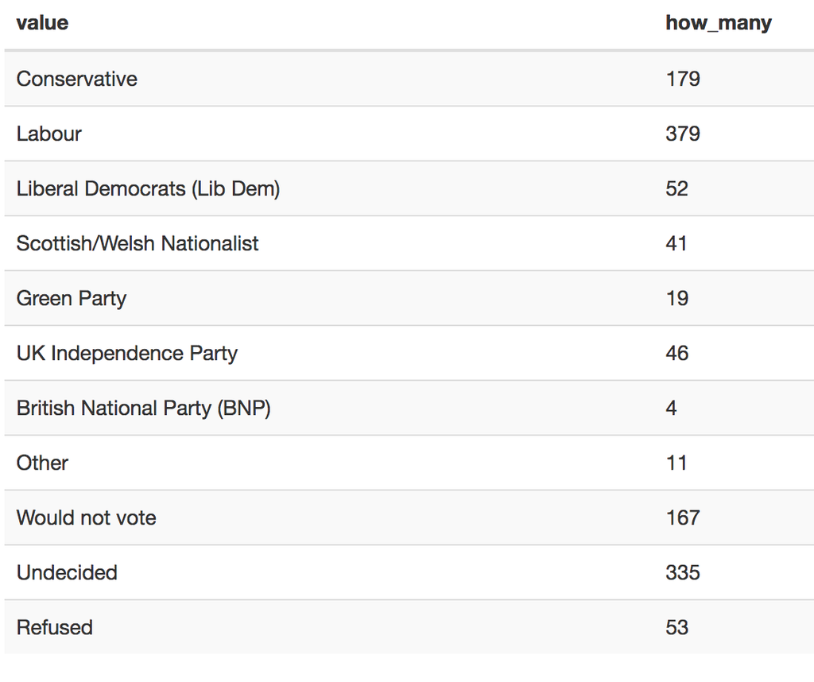

image

- The results are the same as before except that the the text of the value column from the Questions1 table has replaced the numeric value from the Q1 column in the SN7577 table.
- Notice that the the `GROUP BY` column does not appear in the `SELECT clause`.

## Exercise

```sql
SELECT q.value,
       count(*) as how_many
FROM SN7577 s
JOIN Question1  q
ON q.key = s.Q1
GROUP BY  s.Q1
```

1. Change the SQL so that the group by clause is the value column from the Question1 table. Run the query. How are the results different?
2. Can you change the SQL so that table alias’ are not used? Does this aid readability or not?

### Solution:

1. You only have to substitute q.value for `s.Q1` in the `GROUP BY` clause. Essentially the same results are returned but now they are in alphabetical order of the Quustion1 value column text.
- Because there are no conflicts in the column names between the two tables you could write the query without using alias’ for the tables. Including the alias’ adds clarity and readability to the SQL, especially if you are selecting several columns from each of the tables.

## There are severeal different join types possible

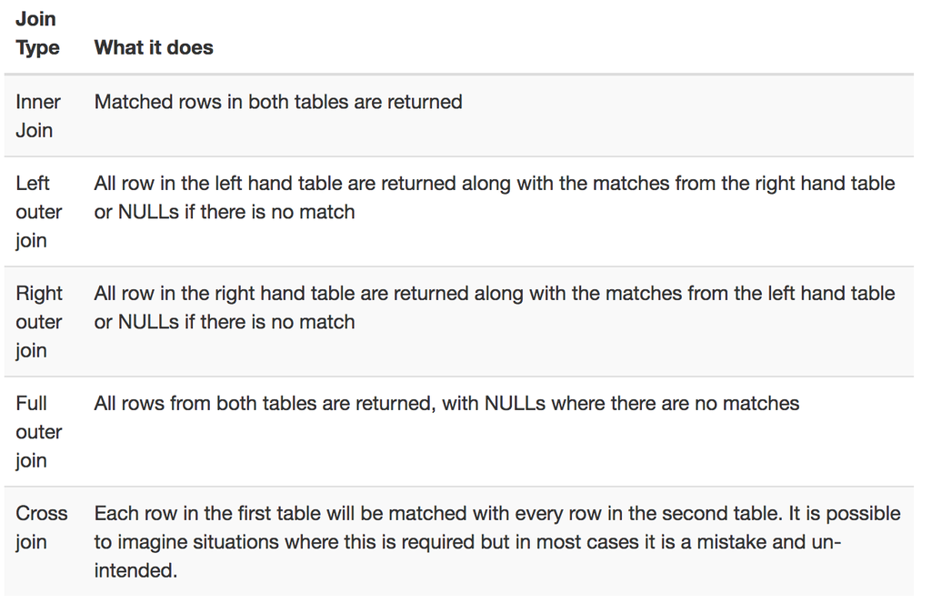

image

In SQLite only the `Inner join`, the `Left Outer join` and the `Cross join` are supported. * You can create a `Right outer join` by swapping the tables in the `From` and `Join` clauses. * A `Full outer join` is the combination of the `Left outer and Right outer joins`.

## Using different join types in analysing your data

- In many cases the data you have in your tables may have come from disperate sources, in that they do not form part of a planned relational database.
- It has been your decision to bring together (join) the data in the tables.
- In order to do this at all you must be confident that the tables of data do have columns which have a common set of values that you can join on.
- Assuming you do have a common column to join on, you can use an `Inner join` to combine the data.
- However it will also be important for you to establish rows in both of the tables for which there is no matching row in the other table.
  - You may expect some to be missing
  - You may not care that some are missing
  - You may need to explain why some are missing
- To do this you will want to use a `Full outer join` or in the case of SQLite a `Left outer join` run twice using both tables in the `From` and `Join` clauses.
- To illustrate the different join types we will use two small example tables

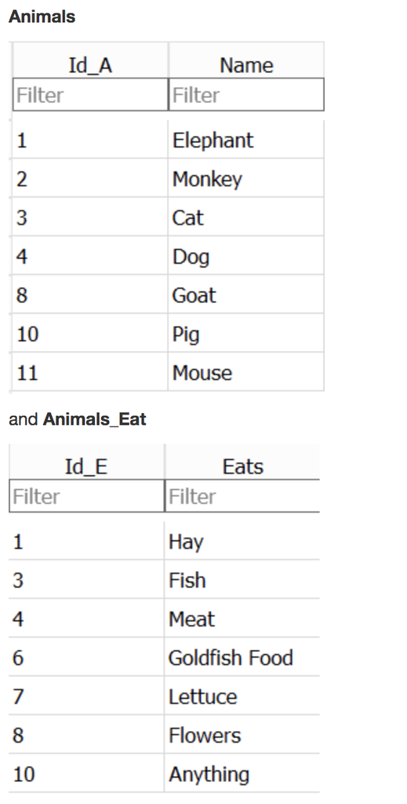

* These tables have been included in the SN7577 database

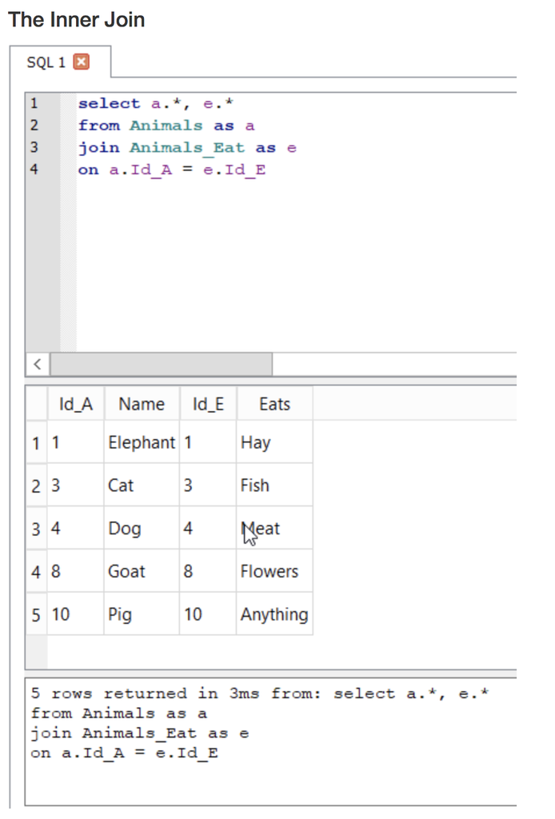

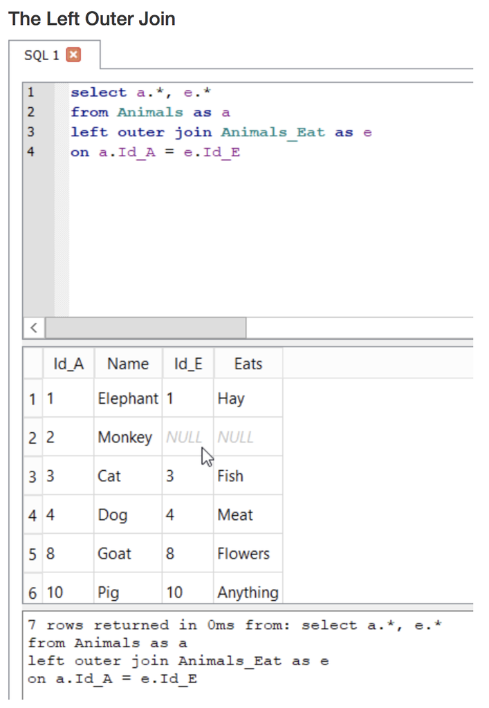

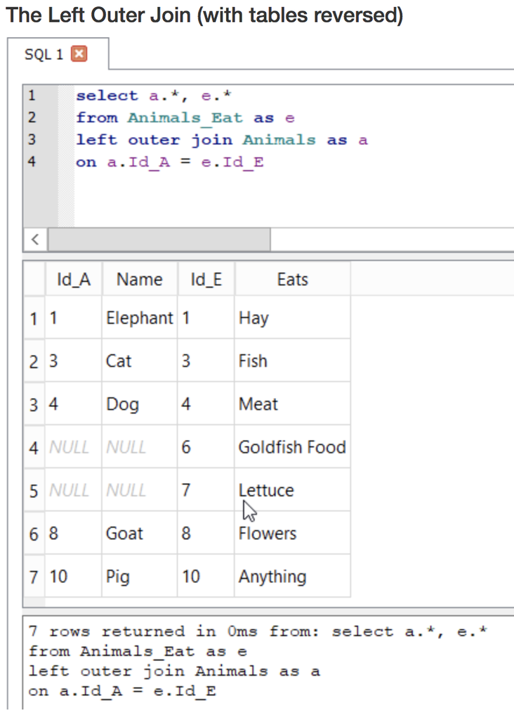

### Exercise

1. Modify the first `Left Outer Join` query above so that only the joined rows where there is no match in the Animals_Eat table are returned.

```sql
SELECT a.*, e.*
FROM Animals as a
LEFT OUTER JOIN Animals_Eat as e
on a.ID_A = e.ID_E
```

2. Modify the second `Left Outer Join` query above so that only the the `Id_E column` from the `Animals_Eat table` is returned where there is no matching row in the Animal table.

```sql
SELECT a.*, e.*
FROM Animals_Eat as a
LEFT OUTER JOIN Animals as a
on a.ID_A = e.ID_E
```

####Solution:

```sql
SELECT a.* , e.*
FROM Animals  as a
Left outer Join  Animals_Eat as e
on  a.Id_A = e.Id_E
where e.Id_e is NULL;
```

```sql
SELECT Id_E
FROM Animals_Eat
Left outer Join Animals
ON  Id_A = Id_E
WHERE Id_A is NULL
ORDER by Id_E;
```

Because there is no conflict in the column names across the two tables, we have chosen not to use alias’. Notice that the Id_A column which we are checking for NULL doesn’t have to be a returned column.

#### key points

- Joins are used to combine data from two or more tables.
- Tables to be joined must have a column in each which represent the same thing
- There are several different types of joins
- The Inner join is the most commonly use
- You may have to use the other join types to discover missing data or gaps in your data